# Walkthrough - Train/Test - Cross-Validation

Jeff

03/17/2026

## Training-testing

Let’s start with discussion surrounding using a training-testing framework for estimating the long-run MSE of a model.

The general rule of thumb…

- The smaller the training set, the larger the bias (specifically, expected overestimation of the MSE)
- The smaller the testing set, the larger the variance (aka, variability of the estimate given a new training set)

We can easily show this via simulations in a linear model context. First, we simulate 1000 data sets of sample size 200, and we’ll plot the first data set as an illustration…

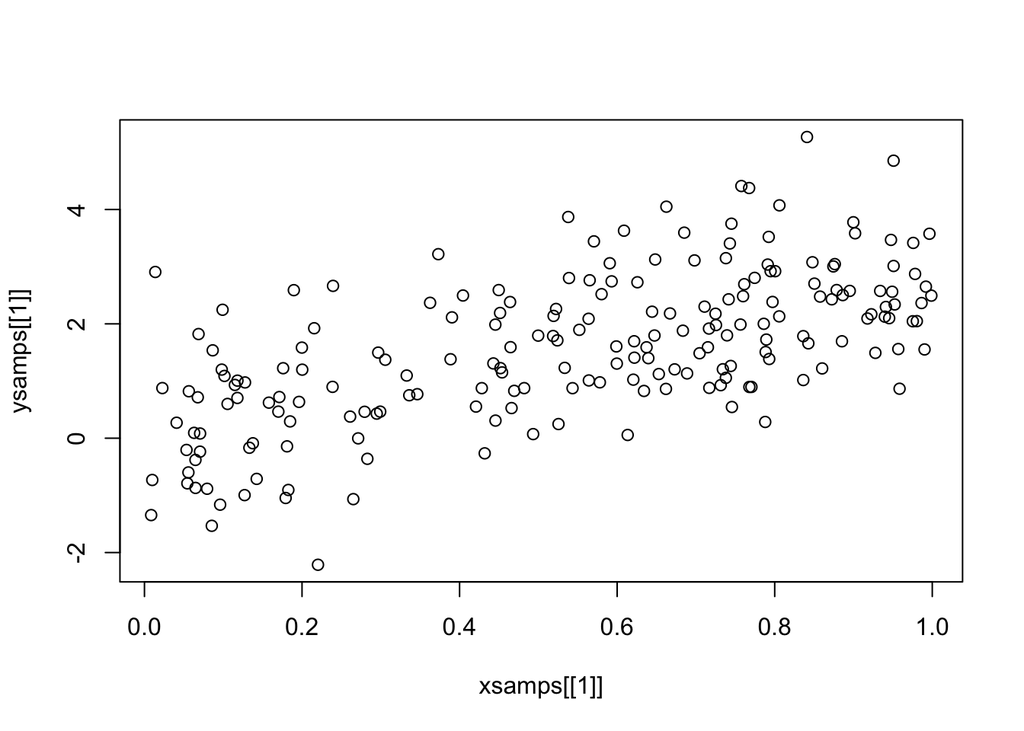

```r
set.seed(4314876)
x <- runif(200000)
y <- 3*x + rnorm(200000)
xsamps <- split(x, ceiling(seq_along(x) / 200))
ysamps <- split(y, ceiling(seq_along(y) / 200))
plot(ysamps[[1]]~xsamps[[1]])
```

Now, we’ll setup (in a super inefficient, non-generalizable code sort of way) 50-50, 80-20, and 20-80 training-testing splits for the 1000 data sets, and fit a linear model on the training data, then estimate the MSE using the test set and store that for future reference.

```r
###50-50 train-test
set.seed(3524362)
allmsett50 <- NA
for(j in 1:1000){
  trind <- sample(1:200, 100)
  xtr <- xsamps[[j]][trind]
  ytr <- ysamps[[j]][trind]
  trlm <- lm(ytr~xtr)
  allmsett50[j] <- sum((predict(trlm, newdata=data.frame(xtr=xsamps[[j]][-trind])) - ysamps[[j]][-trind])^2)/100
}

###80-20 train-test
set.seed(3524362)
allmsett80 <- NA
for(j in 1:1000){
  trind <- sample(1:200, 160)
  xtr <- xsamps[[j]][trind]
  ytr <- ysamps[[j]][trind]
  trlm <- lm(ytr~xtr)
  allmsett80[j] <- sum((predict(trlm, newdata=data.frame(xtr=xsamps[[j]][-trind])) - ysamps[[j]][-trind])^2)/40
}

###20-80 train-test
set.seed(3524362)
allmsett20 <- NA
for(j in 1:1000){
  trind <- sample(1:200, 40)
  xtr <- xsamps[[j]][trind]
  ytr <- ysamps[[j]][trind]
  trlm <- lm(ytr~xtr)
  allmsett20[j] <- sum((predict(trlm, newdata=data.frame(xtr=xsamps[[j]][-trind])) - ysamps[[j]][-trind])^2)/160
}
```

At this point, we have 1000 estimates of the MSE from each framework. So, we can look at a visualization via histograms with the same axes. We’ll plot them in increasing order of training set size

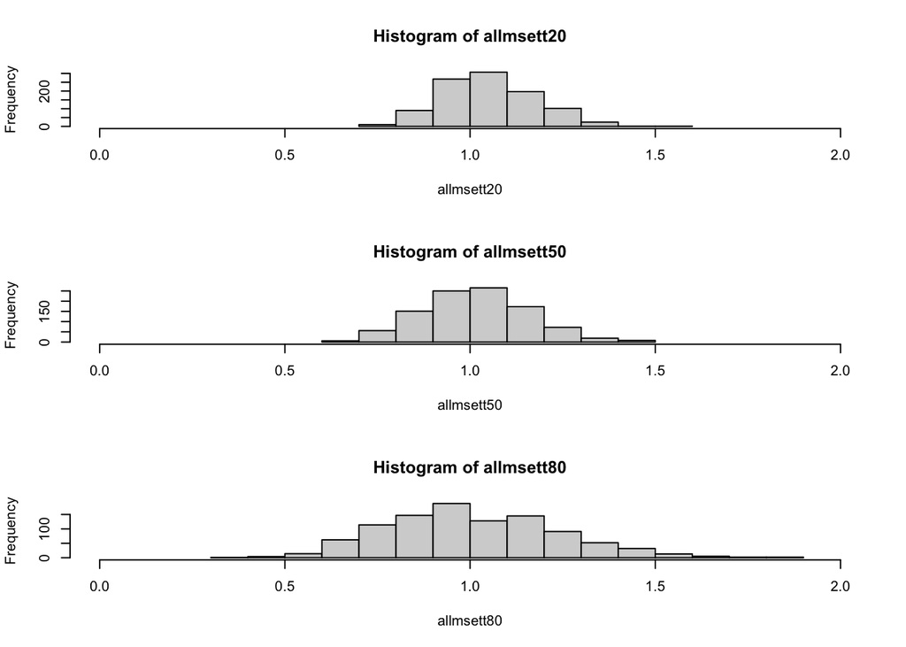

```r
par(mfrow=c(3,1))
hist(allmsett20, xlim=c(0,2))
hist(allmsett50, xlim=c(0,2))
hist(allmsett80, xlim=c(0,2))
```

From the visualization, it’s relatively clear that the spread of the MSE estimates are increasing as the training set size increases (and testing set size decreases). We can double check this by computing the variance of the estimates…

```r
var(allmsett20)
```

```
## [1] 0.01509029
```

```r
var(allmsett50)
```

```
## [1] 0.02056953
```

```r
var(allmsett80)
```

```
## [1] 0.05190814
```

Now, for the bias we need to consider what the true MSE actually is here. Well, the true MSE of our modelling process here is 1 — our assumed model is correct, and the variance of our random normal error term is 1. That means an unbiased estimator for the true MSE should be centred at 1. Visually from the plots, this is hard to tell…but we can compute the sample mean for our different frameworks

```r
mean(allmsett20)
```

```
## [1] 1.049961
```

```r
mean(allmsett50)
```

```
## [1] 1.017743
```

```r
mean(allmsett80)
```

```
## [1] 1.006759
```

In this case we can see that the bias is actually decreasing as our training set size increases!

## Cross-validation

It’s relatively easy to set-up leave-one-out cross-validation yourself for any analysis. Here we can do it for the simple linear model…

```r
data(cars)
attach(cars)
cvlm <- list()
msecv <- NA
for(i in 1:nrow(cars)){
  cvspeed <- speed[-i]
  cvdist <- dist[-i]
  cvlm[[i]] <- lm(cvdist ~ cvspeed)
  msecv[i] <- (predict(cvlm[[i]], newdata=data.frame(cvspeed=speed[i])) - dist[i])^2
}
mean(msecv)
```

```
## [1] 246.4054
```

Which can be compared to the MSE for the regular model fit…

```r
lmfull <- lm(dist~speed)
mean((predict(lmfull)-dist)^2)
```

```
## [1] 227.0704
```

As expected, the MSE for the model fitted on the whole data is lower than that which is predicted using cross validation. However, note that the above is actually a biased (underguessing) estimate of the MSE. This shouldn’t be surprising given your knowledge of training MSEs — they always underestimate the MSE! The unbiased form is divided by `n-2` rather than `n` (2 parameters estimated). So in this case…

```r
sum((predict(lmfull)-dist)^2)/48
```

```
## [1] 236.5317
```

## The variance of CV

While you may have mastered this from DATA 311, I think one of the most difficult concepts surrounding CV is: that the 5-fold CV estimate of the MSE has less variance than the LOOCV estimate of the MSE.

To make the code easy, we’ll use regression trees since you can control the number of folds with the `cv.tree` function. We’ll need to simulate an example so that we can repeatedly generate new data — this is necessary in order to investigate the type of variance we’re discussing: how much a model (or estimate) changes when a new sample is taken.

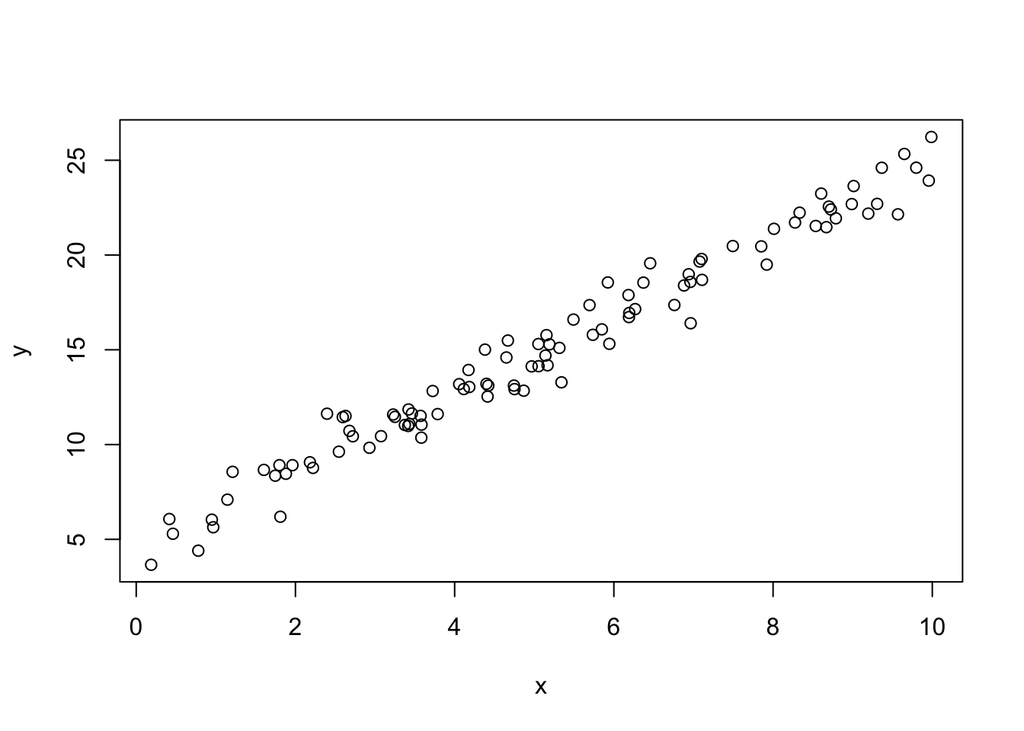

```r
set.seed(21341)
x <- runif(100, 0, 10)
y <- 5 + 2*x + rnorm(100)
plot(y~x)
```

```r
library(tree)
simtree <- tree(y~x)
loocv_simtree <- cv.tree(simtree, K=100)
loocv_RSS <- loocv_simtree$dev[1]
```

Since LOOCV is deterministic, we only need to compute it once for any data set. For the purposes of what we want to discuss though, 5-fold CV will have to be run several times (with the error saved). Off we go…

```r
cv5_RSS <- NA
for(i in 1:500){
  cv5_simtree <- cv.tree(simtree, K=5)
  cv5_RSS[i] <- cv5_simtree$dev[1]
}
```

Now, we’ll give a histogram of the 5-fold estimates, and add the LOOCV estimate in red. BUT: THIS IS NOT ILLUSTRATING VARIANCE!!! WE ARE STILL ONLY LOOKING AT ONE DATA SET :)

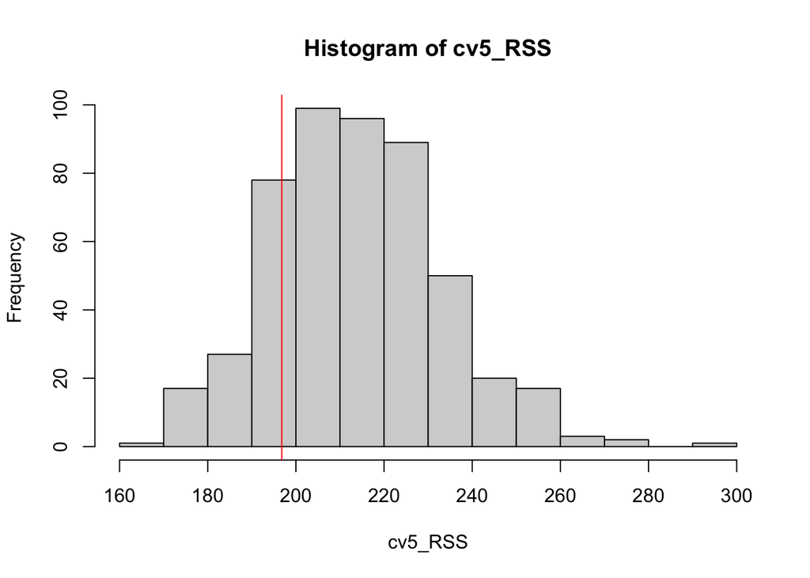

```r
hist(cv5_RSS)
abline(v=loocv_RSS, col="red")
```

We don’t know the true MSE here for this nonparametric model fit to this type of data, but it’s worth noting that the center of the 5-fold estimates does appear above the LOOCV estimate (aka, more potential overestimation).

Now, let’s actually get to the variance part. We need to simulate a whole bunch of data, and we’ll fit both LOOCV and 5-fold-CV once each time…

```r
set.seed(21)
loocv1k <- cv51k <- NA
for(i in 1:500){
  x <- runif(200, 0, 10)
  y <- 5 + 2*x + rnorm(200)
  simtree <- tree(y~x)
  loofit <- cv.tree(simtree, K=200)
  loocv1k[i] <- loofit$dev[1]
  cv5fit <- cv.tree(simtree, K=5)
  cv51k[i] <- cv5fit$dev[1]
}
```

Now, we will plot both separately, but on the same x-limits, for easier viewing…

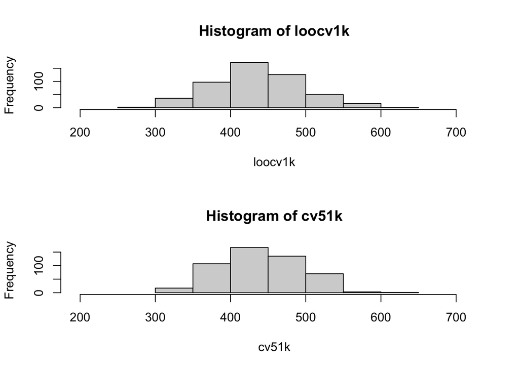

```r
par(mfrow=c(2,1))
xlims <- min(c(loocv1k, cv51k))-100
xlims[2] <- max(c(loocv1k, cv51k))+100
hist(loocv1k, xlim=xlims)
hist(cv51k, xlim=xlims)
```

Or, obviously, literally compute the variance of the estimates…

```r
var(loocv1k)
```

```
## [1] 3476.012
```

```r
var(cv51k)
```

```
## [1] 2738.313
```

## Common mistakes

The biggest issues I see with practitioners is losing track of the primary concern of the setups we use to estimate long-run error. While common sense makes it clear that care needs to be taken in ensuring test sets are blind from the entire process, the more complicated a modeling process is, the more likely mistakes are made!

The same is true for using cross-validation to estimate long run error. Suppose we have some low sample size (50), high dimensional (2000) data and expect to fit a linear model to Y…

```r
set.seed(32531)
X <- matrix(rnorm(100000), 50, 2000)
Y <- rnorm(50)
```

Now we screen variables by selecting the 10 most correlated with Y…

```r
top10 <- which(rank(cor(cbind(Y, X))[-1,1]) %in% 1:10)
```

Then use cross-validation to estimate how our linear model would be expected to perform in the long-run…

```r
cvlm <- list()
msecvW <- NA
Xtop <- data.frame(X[, top10])
for(i in 1:nrow(X)){
  cvY <- Y[-i]
  cvlm[[i]] <- lm(cvY ~., data=Xtop[-i,])
  msecvW[i] <- (predict(cvlm[[i]], newdata=Xtop[i,]) - Y[i])^2
}
mean(msecvW)
```

```
## [1] 0.3683592
```

So our estimated MSE is approx 0.37. What’s the problem? … Y is actually independent of X!!! Therefore our true MSE is the variance of Y. Our pre-screening is basically performing false discovery of variables on the FULL data (including the left out ones), and then our CV is running on those false discoveries. We need to implement the screening WITHIN the CV process…

```r
cvlm <- list()
msecvR <- NA
for(i in 1:nrow(X)){
  cvtop10 <- which(rank(cor(cbind(Y[-i], X[-i,]))[-1,1]) %in% 1:10)
  cvXtop10 <- data.frame(X[, cvtop10])
  cvY <- Y[-i]
  cvlm[[i]] <- lm(cvY ~., data=cvXtop10[-i,])
  msecvR[i] <- (predict(cvlm[[i]], newdata=cvXtop10[i,]) - Y[i])^2
}
mean(msecvR)
```

```
## [1] 1.310286
```

See the difference! We can visualize with histograms too…

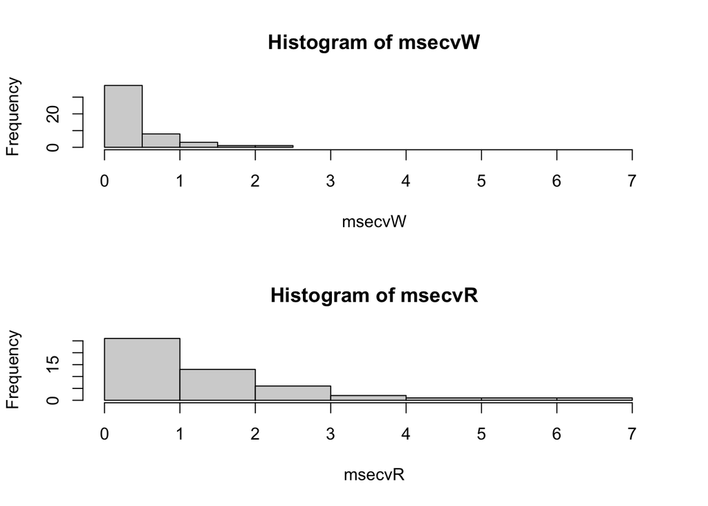

```r
par(mfrow=c(2,1))
xlims <- 0
xlims[2] <- max(c(msecvW, msecvR))+1
hist(msecvW, xlim=xlims)
hist(msecvR, xlim=xlims)
```